# 6 Anexo — Dados Climáticos via Copernicus Climate Data Store

Acesso, configuração e download de dados ERA5-Land com R

Autor

Curso de Análise de Dados de Clima e Saúde — CISC

Data de Publicação

01/07/2026

# 7 Apresentação

Este anexo apresenta o **Copernicus Climate Data Store (CDS)**, uma plataforma gratuita e aberta mantida pelo **Serviço de Mudanças Climáticas Copernicus (C3S)** da União Europeia, que disponibiliza reanálises climáticas globais de alta qualidade para uso científico e técnico.

No contexto do curso CISC, o CDS é utilizado como fonte de dados climáticos diários — temperatura do ar, ponto de orvalho e precipitação — a partir do produto **ERA5-Land**, com cobertura histórica a partir de 1950 e atualização regular com poucos dias de defasagem.

**NotaPor que usar o ERA5-Land?**

O **ERA5-Land** é uma reanálise climática de alta resolução (~9 km de grade) produzida pelo **ECMWF** (*European Centre for Medium-Range Weather Forecasts*). Suas principais vantagens para vigilância em saúde são:

- **Cobertura espacial contínua**: sem lacunas causadas por ausência de estações meteorológicas
- **Cobertura temporal longa**: a partir de 1950, com atualização frequente
- **Variáveis relevantes para saúde**: temperatura, umidade, precipitação, velocidade do vento, entre outras
- **Acesso livre e gratuito**: via API com cadastro simples

# 8 Acessando o Copernicus Climate Data Store

## 8.1 Navegando até o CDS

O ponto de entrada é o portal principal do Copernicus, em [**climate.copernicus.eu**](https://climate.copernicus.eu).

[figure not shown]

Página principal do portal Copernicus Climate Change Service.

Na barra de navegação superior, clique na aba **Data** para acessar os produtos disponíveis.

[figure not shown]

A aba “Data” na barra de navegação do portal Copernicus.

## 8.2 O Climate Data Store

Após clicar em **Data**, você será direcionado à página do **Climate Data Store (CDS)** — o repositório central de dados climáticos do Copernicus.

[figure not shown]

Página inicial do Climate Data Store.

Para explorar os produtos disponíveis, clique na aba **Datasets**.

[figure not shown]

A aba “Datasets” na barra de navegação do CDS.

A página de *Datasets* lista os produtos disponíveis para download, incluindo o ERA5-Land que utilizaremos neste curso.

[figure not shown]

Catálogo de datasets disponíveis no CDS.

# 9 Criando uma conta no ECMWF

Para baixar dados, é necessário criar uma conta gratuita no ECMWF. O acesso é vinculado à chave de API pessoal que será utilizada no script R.

## 9.1 Iniciando o cadastro

Na página inicial do CDS, clique em **Login / Register** no canto superior direito.

[figure not shown]

Opção de Login/Register na página inicial do CDS.

Você será redirecionado para a página de autenticação do ECMWF.

[figure not shown]

Página de login do ECMWF.

Como ainda não possui conta, clique na opção de **criar uma nova conta**.

[figure not shown]

Opção de criação de conta na página de login.

## 9.2 Preenchendo os dados de cadastro

Preencha os campos obrigatórios: nome, sobrenome, endereço de e-mail e senha.

[figure not shown]

Formulário inicial de criação de conta: nome, sobrenome, e-mail e senha.

Após submeter o formulário, o sistema enviará um e-mail de verificação.

[figure not shown]

Confirmação de envio do e-mail de verificação.

## 9.3 Verificando o e-mail

Acesse sua caixa de entrada e abra o e-mail recebido do ECMWF. Clique no link de confirmação para continuar o cadastro.

[figure not shown]

E-mail de verificação enviado pelo ECMWF com link de ativação.

## 9.4 Complementando o perfil

Ao clicar no link, você será redirecionado para uma segunda etapa de cadastro, onde deverá informar: país, afiliação, organização, atividade temática e setor de atividade. Também é necessário marcar a opção de aceite dos termos de uso.

[figure not shown]

Segunda etapa do cadastro: informações institucionais e termos de uso.

Com todos os campos preenchidos, clique no botão para **ativar a conta**.

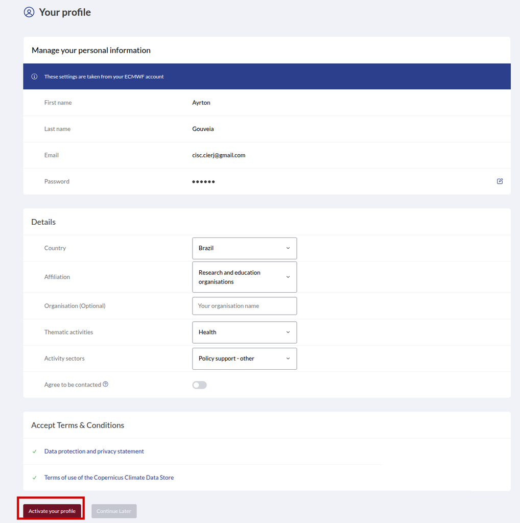

Formulário preenchido e botão de ativação da conta destacado.

# 10 Configurando o acesso à API

## 10.1 Confirmando o login

Após ativar a conta e fazer login, o CDS exibirá seu nome de usuário no canto superior direito, confirmando que você está autenticado.

[figure not shown]

Nome do usuário logado exibido no canto superior direito do CDS.

## 10.2 Aceitando as licenças de uso

Clique no seu nome de usuário e acesse a aba **Licenses**. É necessário aceitar as licenças dos datasets que deseja utilizar antes de efetuar qualquer download.

**ImportanteAtenção: licenças obrigatórias**

Sem aceitar as licenças correspondentes, as requisições de download via API **serão recusadas**, mesmo com a chave configurada corretamente. Certifique-se de aceitar a licença do ERA5-Land antes de executar o script.

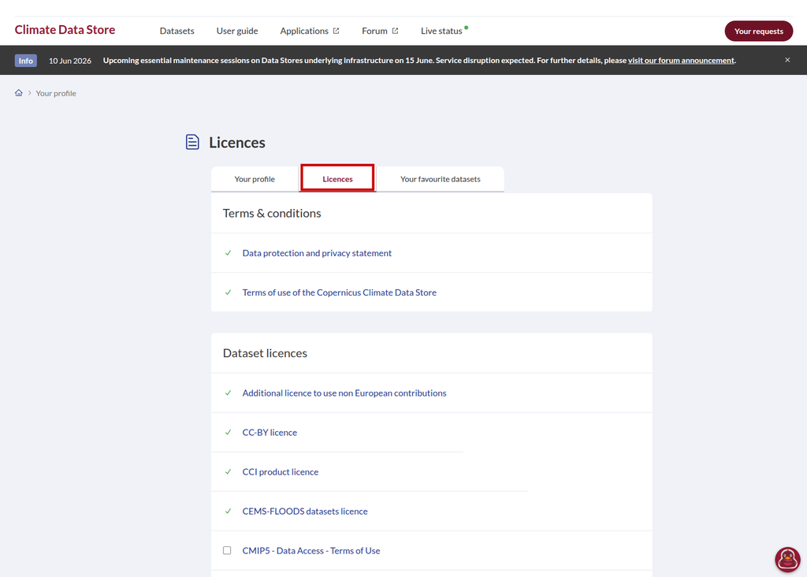

Aba “Licenses” no perfil do usuário, com opções de licença para aceite.

## 10.3 Obtendo a chave da API

Na mesma área do perfil, acesse a aba **Your profile**. Lá você encontrará:

1. A opção de **revelar a chave da API** (*API key*)
2. A **chave em si**, que deverá ser copiada e colada no script R

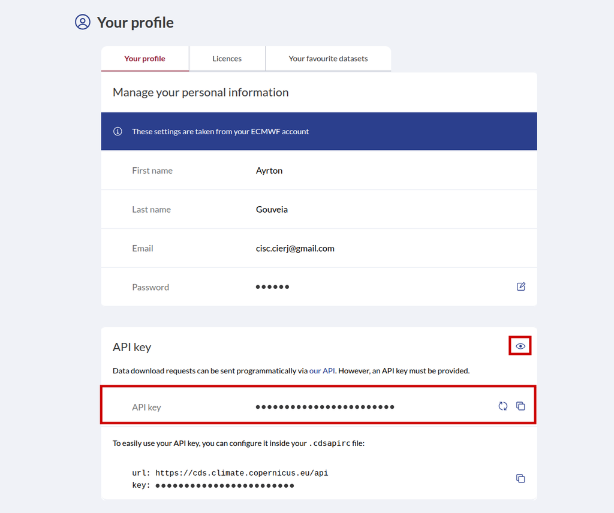

Aba “Your profile” com opção de revelar e copiar a chave da API.

**DicaGuarde sua chave com cuidado**

A chave da API é **pessoal e intransferível**. Não a compartilhe publicamente (por exemplo, em repositórios GitHub abertos). No script do curso, ela é atribuída a uma variável local que **não deve ser incluída em arquivos versionados**.

# 11 Script R — Download e processamento dos dados ERA5-Land

Com a conta criada, licenças aceitas e a chave da API em mãos, você já pode baixar os dados diretamente pelo R, utilizando o pacote `ecmwfr`.

O script a seguir realiza o download dos dados do ERA5-Land para um município de interesse, processa os arquivos NetCDF resultantes e gera um `data.frame` final com as seguintes variáveis diárias:

Variáveis climáticas geradas pelo script ERA5-Land

| Variável | Descrição | Unidade |
| --- | --- | --- |
| `t2m_mean` | Temperatura média diária a 2 metros | °C |
| `t2m_max` | Temperatura máxima diária a 2 metros | °C |
| `t2m_min` | Temperatura mínima diária a 2 metros | °C |
| `d2m_mean` | Temperatura de ponto de orvalho média | °C |
| `d2m_max` | Temperatura de ponto de orvalho máxima | °C |
| `d2m_min` | Temperatura de ponto de orvalho mínima | °C |
| `tp_mm` | Precipitação total diária | mm |
| `rh_mean` | Umidade relativa média (derivada de t2m e d2m) | % |
| `rh_max` | Umidade relativa máxima | % |
| `rh_min` | Umidade relativa mínima | % |

**NotaTemperatura de ponto de orvalho e umidade relativa**

O ERA5-Land não fornece umidade relativa diretamente. O script calcula a umidade relativa (**rh**) a partir da temperatura do ar (**t2m**) e da temperatura de ponto de orvalho (**d2m**) usando a **fórmula de Magnus**:

$$RH = 100 \times \frac{\exp\!\left(\dfrac{17{,}625 \times T_{d}}{243{,}04 + T_{d}}\right)}{\exp\!\left(\dfrac{17{,}625 \times T}{243{,}04 + T}\right)}$$

onde $T_d$ é o ponto de orvalho e $T$ é a temperatura do ar (ambos em °C). Os valores são truncados no intervalo [0, 100].

## 11.1 Pacotes necessários

**Mostrar código**

```r
# ============================================================
# Verificação e instalação automática de pacotes
# ============================================================

pacotes_obrigatorios <- c(
  "ecmwfr",     # interface com a API do CDS
  "tidyverse",  # manipulação de dados
  "purrr",      # iteração funcional
  "ncdf4",      # leitura de arquivos NetCDF
  "terra",      # processamento de rasters
  "sf",         # dados espaciais vetoriais
  "geobr",      # limites municipais do Brasil
  "lubridate"   # manipulação de datas
)

pacotes_ausentes <- pacotes_obrigatorios[
  !sapply(pacotes_obrigatorios, require, character.only = TRUE, quietly = TRUE)
]

if (length(pacotes_ausentes) > 0) {
  message("Instalando pacotes ausentes: ",
          paste(pacotes_ausentes, collapse = ", "))
  install.packages(pacotes_ausentes, dependencies = TRUE)

  carregados <- sapply(pacotes_ausentes, require, character.only = TRUE, quietly = TRUE)

  if (!all(carregados)) {
    stop("Falha ao carregar alguns pacotes: ",
         paste(pacotes_ausentes[!carregados], collapse = ", "))
  }
}
```

## 11.2 Configuração da chave de API

**Mostrar código**

```r
# ============================================================
# Substitua pelo valor copiado da aba "Your profile" no CDS
# ============================================================

key_CDO <- "COLE_SUA_CHAVE_AQUI"

# Registra a chave na sessão R — necessário antes de qualquer download
wf_set_key(key = key_CDO)
```

**ImportanteOnde obter a chave?**

Acesse [**cds.climate.copernicus.eu**](https://cds.climate.copernicus.eu) → clique no seu nome de usuário → aba **Your profile** → botão para revelar a chave → copie e cole acima, substituindo `"COLE_SUA_CHAVE_AQUI"`.

## 11.3 Área de interesse

**Mostrar código**

```r
# ============================================================
# Define a área de download a partir do limite municipal (geobr)
# Substitua o código IBGE pelo do município de interesse
# ============================================================

# Exemplo: Rio de Janeiro (código IBGE 3304557)
shape  <- geobr::read_municipality(code_muni = 3304557, year = 2020)
aoi_bb <- sf::st_bbox(shape)

# Formato exigido pelo CDS: norte, oeste, sul, leste
area <- c(aoi_bb["ymax"], aoi_bb["xmin"], aoi_bb["ymin"], aoi_bb["xmax"])
```

**DicaAdaptando para outro município**

Basta substituir o `code_muni` pelo código IBGE de 7 dígitos do município desejado. O bounding box é calculado automaticamente a partir do polígono municipal.

Para obter o código IBGE, consulte [ibge.gov.br/cidades-e-estados](https://www.ibge.gov.br/cidades-e-estados.html).

## 11.4 Seleção do período

O script oferece quatro opções de seleção de datas. Escolha a que melhor se adapta ao seu fluxo de trabalho e atribua à variável `datas_interesse`.

**Mostrar código**

```r
# ============================================================
# OPÇÃO 1 — Datas específicas (lista manual)
# ============================================================
datas_especificas <- as.Date(c(
  "2023-11-17",
  "2023-11-18",
  "2023-11-19"
))

# ============================================================
# OPÇÃO 2 — Combinações de ano × mês × dia
# ============================================================
# anos   <- c(2023, 2024)
# meses  <- c(11, 12, 1)
# dias   <- c(1, 15)
#
# datas_por_componente <- expand_grid(
#   year  = anos,
#   month = meses,
#   day   = dias
# ) %>%
#   mutate(date = make_date(year, month, day)) %>%
#   filter(!is.na(date)) %>%
#   pull(date)

# ============================================================
# OPÇÃO 3 — Intervalo contínuo entre duas datas
# ============================================================
# datas_intervalo <- seq(
#   as.Date("2023-11-01"),
#   as.Date("2023-11-30"),
#   by = "day"
# )

# ============================================================
# OPÇÃO 4 — Do início do ano até ontem (pipeline automático)
# ============================================================
# datas_ate_ontem <- seq(
#   as.Date("2023-01-01"),
#   Sys.Date() - 1,
#   by = "day"
# )

# ── Selecione qual opção usar ──────────────────────────────
datas_interesse <- datas_especificas  # <- troque aqui

# Agrupa por ano-mês para montar as requisições ao CDS
ym <- datas_interesse %>%
  as_tibble() %>%
  rename(date = value) %>%
  mutate(year = year(date), month = month(date), day = day(date)) %>%
  group_by(year, month) %>%
  summarise(days = list(day), .groups = "drop")

print(ym)
```

## 11.5 Funções auxiliares

### 11.5.1 Função de download

**Mostrar código**

```r
# ============================================================
# download_era5_days()
# Baixa um arquivo NetCDF por variável e por mês,
# pulando arquivos já existentes no diretório de saída.
# ============================================================

download_era5_days <- function(year, month, days, variavel, prefix,
                               dir_out = "./era5/") {
  dir.create(dir_out, showWarnings = FALSE, recursive = TRUE)

  target <- paste0(prefix, "_", year, sprintf("%02d", month), ".nc")

  # Evita redownload de arquivos já existentes
  if (file.exists(file.path(dir_out, target))) {
    cat("⏭ já existe:", target, "\n")
    return(invisible(NULL))
  }

  request <- list(
    dataset_short_name = "reanalysis-era5-land",
    product_type       = "reanalysis",
    variable           = variavel,
    year               = as.character(year),
    month              = sprintf("%02d", month),
    day                = sprintf("%02d", days),
    time               = sprintf("%02d:00", 0:23),  # todas as horas (24 layers/dia)
    data_format        = "netcdf",
    download_format    = "unarchived",
    area               = area,
    target             = target
  )

  tryCatch({
    wf_request(request = request, transfer = TRUE,
               path = dir_out, verbose = TRUE)
    cat("✓", prefix, year, sprintf("%02d", month),
        "dias:", paste(days, collapse = ", "), "\n")
  }, error = function(e) {
    cat("✗", prefix, year, sprintf("%02d", month), ":", e$message, "\n")
    write_lines(
      paste(prefix, year, month, "FAILED"),
      file.path(dir_out, "failed.txt"),
      append = TRUE
    )
  })
}
```

### 11.5.2 Função de processamento NetCDF → data.frame

**Mostrar código**

```r
# ============================================================
# nc_to_df()
# Converte um arquivo NetCDF horário em um data.frame diário,
# aplicando a estatística escolhida (mean, max, min, sum)
# e convertendo unidades:
#   - temperatura: Kelvin → °C  (−273,15)
#   - precipitação: m → mm      (×1000)
# ============================================================

nc_to_df <- function(nc_path, varname,
                     stat = c("mean", "max", "min", "sum")) {
  stat <- match.arg(stat)

  r        <- rast(nc_path)
  n_layers <- nlyr(r)
  n_days   <- n_layers / 24
  day_idx  <- rep(1:n_days, each = 24)

  # Agrega 24 camadas horárias em 1 camada diária
  if (n_days == 1) {
    r_daily <- app(r, fun = stat)
    names(r_daily) <- "lyr1"
  } else {
    r_daily <- tapp(r, day_idx, fun = stat)
  }

  # Conversão de unidades
  varname_base <- str_extract(varname, "^[a-z0-9]+")
  if (varname_base == "tp") {
    r_daily <- r_daily * 1000       # m → mm
  } else {
    r_daily <- r_daily - 273.15     # K → °C
  }

  # Extrai datas a partir dos metadados do arquivo NetCDF
  nc    <- ncdf4::nc_open(nc_path)
  tempo <- ncdf4::ncvar_get(nc, "valid_time")
  ncdf4::nc_close(nc)

  datas <- as.Date(as.POSIXct(
    tempo[seq(1, length(tempo), by = 24)],
    origin = "1970-01-01", tz = "UTC"
  ))

  as.data.frame(r_daily, xy = TRUE) %>%
    rename(lon = x, lat = y) %>%
    pivot_longer(cols = -c(lon, lat),
                 names_to = "day_idx", values_to = varname) %>%
    mutate(
      day_idx = as.integer(str_extract(day_idx, "\\d+")),
      date    = datas[day_idx]
    ) %>%
    select(lon, lat, date, all_of(varname))
}
```

## 11.6 Executando o download

**Mostrar código**

```r
# ============================================================
# Variáveis para download
# t2m = temperatura a 2 m (Kelvin → °C)
# d2m = ponto de orvalho a 2 m (Kelvin → °C)
# tp  = precipitação total (m → mm)
# ============================================================

variaveis <- list(
  list(variavel = "2m_temperature",          prefix = "t2m"),
  list(variavel = "2m_dewpoint_temperature", prefix = "d2m"),
  list(variavel = "total_precipitation",     prefix = "tp")
)

# Itera sobre variáveis e meses
walk(variaveis, function(v) {
  cat("\n⬇ Baixando", v$prefix, "\n")
  pwalk(ym, function(year, month, days) {
    download_era5_days(year, month, days, v$variavel, v$prefix)
  })
})
```

**NotaTempo de download**

O CDS processa as requisições em fila. Dependendo do volume de dados e da carga do servidor, cada arquivo pode levar de **segundos a vários minutos**. O pacote `ecmwfr` aguarda automaticamente e exibe o progresso no console.

Arquivos já baixados são automaticamente pulados (verificação por nome de arquivo).

## 11.7 Processando os arquivos NetCDF

**Mostrar código**

```r
# ============================================================
# Lista os arquivos baixados por variável
# ============================================================

arquivos_t2m <- list.files("./era5/", pattern = "^t2m_.*\\.nc$", full.names = TRUE)
arquivos_d2m <- list.files("./era5/", pattern = "^d2m_.*\\.nc$", full.names = TRUE)
arquivos_tp  <- list.files("./era5/", pattern = "^tp_.*\\.nc$",  full.names = TRUE)

# Processa cada conjunto de arquivos com as estatísticas diárias
df_t2m_mean <- map_dfr(arquivos_t2m, nc_to_df, varname = "t2m_mean", stat = "mean")
df_t2m_max  <- map_dfr(arquivos_t2m, nc_to_df, varname = "t2m_max",  stat = "max")
df_t2m_min  <- map_dfr(arquivos_t2m, nc_to_df, varname = "t2m_min",  stat = "min")
df_d2m_mean <- map_dfr(arquivos_d2m, nc_to_df, varname = "d2m_mean", stat = "mean")
df_d2m_max  <- map_dfr(arquivos_d2m, nc_to_df, varname = "d2m_max",  stat = "max")
df_d2m_min  <- map_dfr(arquivos_d2m, nc_to_df, varname = "d2m_min",  stat = "min")
df_tp_sum   <- map_dfr(arquivos_tp,  nc_to_df, varname = "tp_mm",    stat = "sum")
```

## 11.8 Consolidando o data.frame final

**Mostrar código**

```r
# ============================================================
# Integra todas as variáveis e calcula a umidade relativa
# ============================================================

df_final <- df_t2m_mean %>%
  left_join(df_t2m_max,  by = c("lon", "lat", "date")) %>%
  left_join(df_t2m_min,  by = c("lon", "lat", "date")) %>%
  left_join(df_d2m_mean, by = c("lon", "lat", "date")) %>%
  left_join(df_d2m_max,  by = c("lon", "lat", "date")) %>%
  left_join(df_d2m_min,  by = c("lon", "lat", "date")) %>%
  left_join(df_tp_sum,   by = c("lon", "lat", "date")) %>%
  filter(date %in% datas_interesse) %>%
  mutate(
    # Precipitação: trata NA como zero (ausência de chuva)
    tp_mm = replace_na(tp_mm, 0),

    # Umidade relativa via fórmula de Magnus (truncada em [0, 100])
    rh_mean = pmin(100, pmax(0,
      100 * exp(17.625 * d2m_mean / (243.04 + d2m_mean)) /
            exp(17.625 * t2m_mean / (243.04 + t2m_mean)))),

    # rh_max: orvalho máximo / temperatura mínima (condição mais úmida)
    rh_max  = pmin(100, pmax(0,
      100 * exp(17.625 * d2m_max  / (243.04 + d2m_max))  /
            exp(17.625 * t2m_min  / (243.04 + t2m_min)))),

    # rh_min: orvalho mínimo / temperatura máxima (condição mais seca)
    rh_min  = pmin(100, pmax(0,
      100 * exp(17.625 * d2m_min  / (243.04 + d2m_min))  /
            exp(17.625 * t2m_max  / (243.04 + t2m_max))))
  ) %>%
  arrange(date, lat, lon)

# Estrutura esperada do data.frame final:
# lon | lat | date | t2m_mean | t2m_max | t2m_min |
# d2m_mean | d2m_max | d2m_min | tp_mm |
# rh_mean  | rh_max  | rh_min

glimpse(df_final)
```

## 11.9 Salvando o resultado

**Mostrar código**

```r
# ============================================================
# Salva em formato .rds para uso nas análises do boletim
# ============================================================

saveRDS(df_final, "./era5/era5_completo.rds")

# Para carregar posteriormente:
# df_final <- readRDS("./era5/era5_completo.rds")
```

**DicaIntegrando ao boletim**

O arquivo `era5_completo.rds` pode ser lido diretamente no `modelo_boletim_saude_clima_cisc.qmd`, na seção de importação de bases climáticas:

```r
clima <- readRDS(file.path(dir_dados_proc, "era5_completo.rds"))
```

Adapte o caminho conforme a estrutura de diretórios do seu projeto.

# 12 Resumo do fluxo de trabalho

**NotaFluxo completo em 5 etapas**

1. **Criar conta** em cds.climate.copernicus.eu e aceitar as licenças de uso
2. **Copiar a chave** da API na aba *Your profile*
3. **Configurar o script**: colar a chave, definir o código IBGE do município e o período de interesse
4. **Executar o download**: o script requisita os dados ao CDS e aguarda a resposta
5. **Processar e salvar**: os arquivos NetCDF são convertidos em um `data.frame` diário e salvos em `.rds`

# 13 Referências e recursos adicionais

- **Copernicus Climate Data Store:** cds.climate.copernicus.eu
- **Documentação do ERA5-Land:** confluence.ecmwf.int/display/CKB/ERA5-Land
- **Pacote `ecmwfr`:** github.com/bluegreen-labs/ecmwfr
- **Pacote `terra`:** [rspatial.org/terra](https://rspatial.org/terra/)
- **geobr:** ipeagit.ipea.gov.br/displaydATA/geobr

**Mostrar código**

```r
# ============================================================
# Informações da sessão R (reprodutibilidade)
# ============================================================

sessionInfo()
```